# Sierra Nevada Time Series

J. Beem-Miller

21 Oct 2020

# Data preparation script for Sierra Nevada time series analysis

*Merge templates with 14C, C, and N data*

Radiocarbon analyses for the 2001 samples were not run originally, but were completed on archived samples in 2020.

## 2001 mean radiocarbon profiles

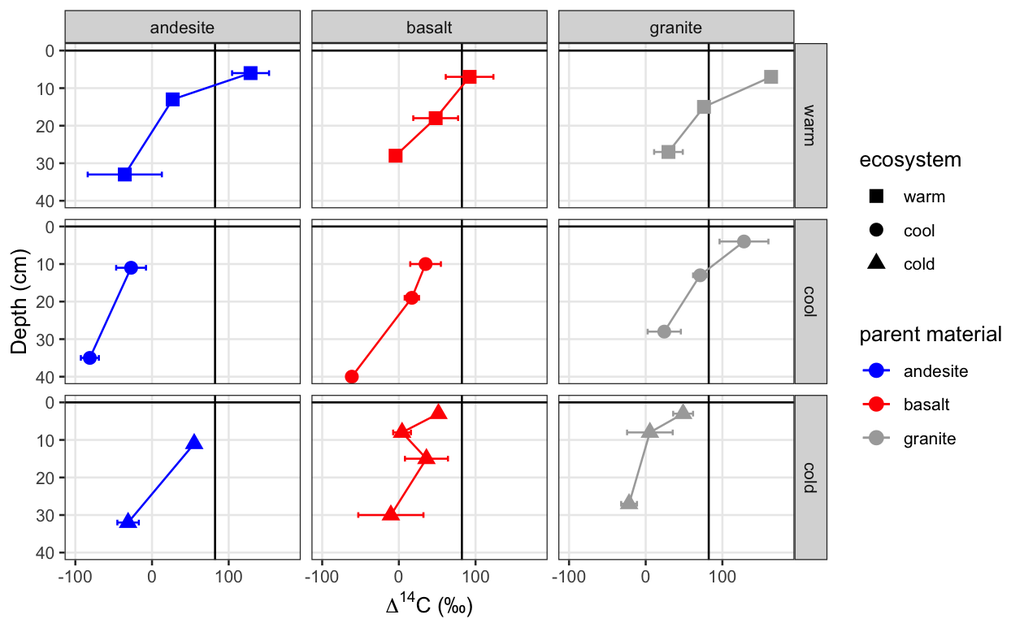

> **Fig. 10. Mean profile $\Delta$<sup>14</sup>C for 2001 samples**

> *Caption:* Mean $\Delta$<sup>14</sup>C by depth for each site in 2001. Error bars show ±1 standard deviation, solid vertical line shows $\Delta$<sup>14</sup>C of the atmosphere in the year of sampling.

## 2009 radiocarbon profiles

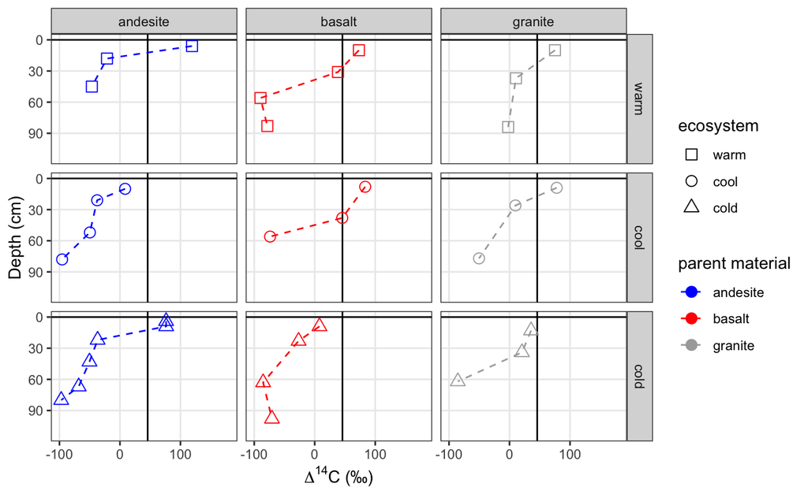

> **Fig. 10. Profile $\Delta$<sup>14</sup>C for 2009 samples**

> *Caption:* Profile $\Delta$<sup>14</sup>C by depth for each site in 2009. Solid vertical line shows $\Delta$<sup>14</sup>C of the atmosphere in the year of sampling. Error bars not shown as only a single replicate profile was analyzed per site.

## 2019 mean radiocarbon profiles

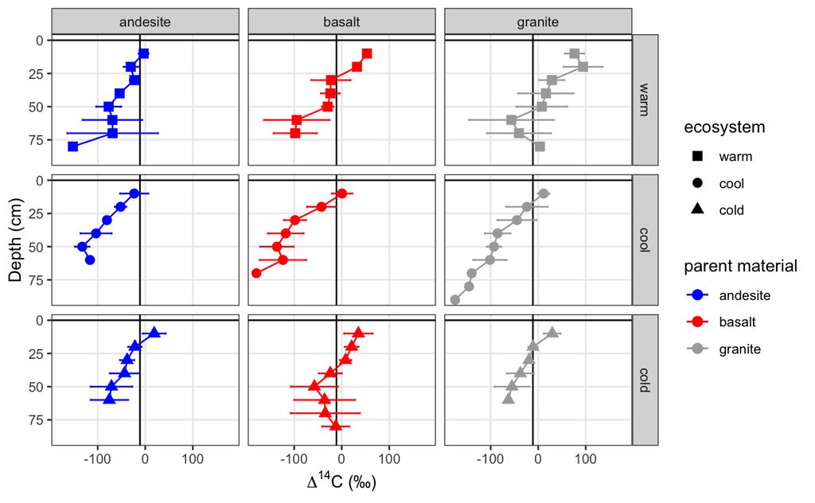

> **Fig. 10. Mean profile $\Delta$<sup>14</sup>C for 2019 samples**

> *Caption:* Mean $\Delta$<sup>14</sup>C by depth for each site in 2019. Error bars show ±1 standard deviation, solid vertical line shows $\Delta$<sup>14</sup>C of the atmosphere in the year of sampling.

## Change in $\Delta$<sup>14</sup>C over time between 2001 and 2019

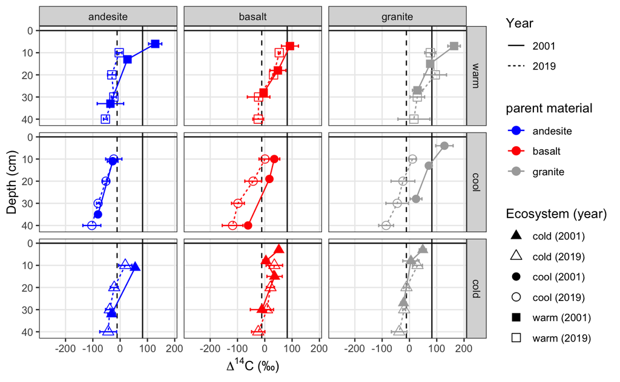

> **Fig. 10. Mean profile $\Delta$<sup>14</sup>C for 2001 and 2019 samples**

> *Caption:* Mean $\Delta$<sup>14</sup>C by depth for each site in 2001 and 2019. Error bars show ±1 standard deviation. Vertical lines show $\Delta$<sup>14</sup>C of the atmosphere in 2001 (solid) and 2019 (dashed).

## Incubation $\Delta$<sup>14</sup>C-CO<sub>2</sub> for 2019 bulk soils

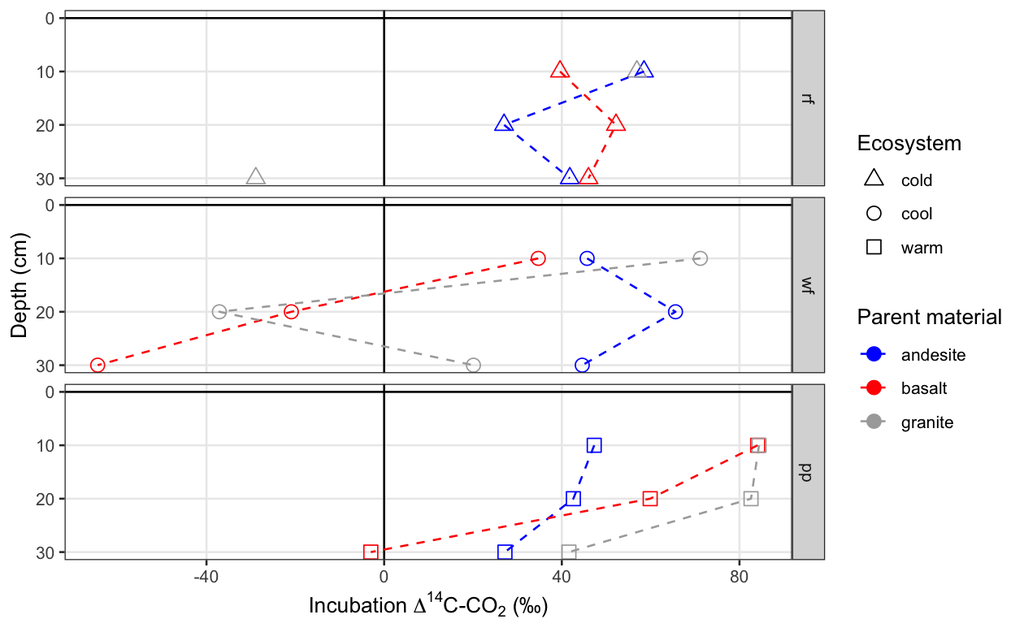

> **Fig. 10. Rep 1 $\Delta$<sup>14</sup>C-CO<sub>2</sub> of 2019 bulk soil incubations**

> *Caption:* $\Delta$<sup>14</sup>CO<sub>2</sub> by depth for each site in 2019. (Still waiting for data from laboratory duplicates). Note that the 10-20 cm increment sample from the cold granite site appears to have been contaminated: $\Delta$<sup>14</sup>C-CO<sub>2</sub> = -396.7.

## Incubation vs. bulk soil $\Delta$<sup>14</sup>C

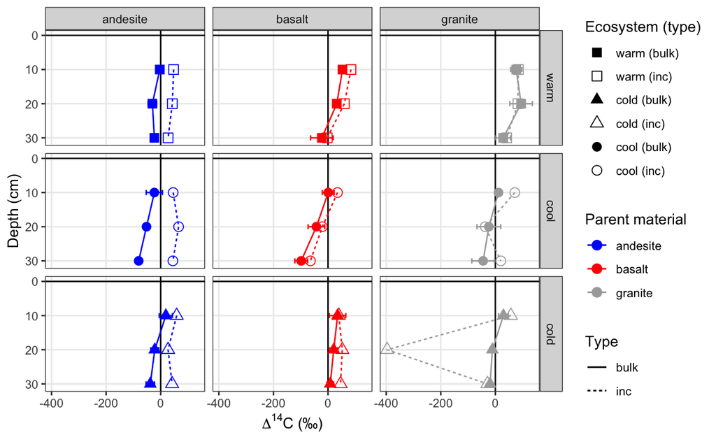

> **Fig. 10. $\Delta$<sup>14</sup>C of 2019 bulk soil incubations and corresponding bulk soil**

> *Caption:* $\Delta$<sup>14</sup>C of bulk soil and respired CO<sub>2</sub> by depth for each site in 2019. Error bars show one standard deviation for bulk soil, points show mean of three replicate profiles for bulk soils and single observations for respired CO<sub>2</sub> (still waiting for data from laboratory duplicates).

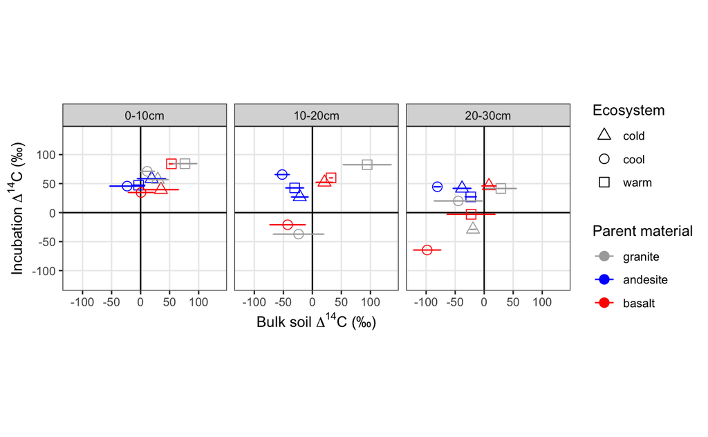

> **Fig. 10. Regression of 2019 bulk soil incubations and corresponding bulk soil $\Delta$<sup>14</sup>C**

> *Caption:* Regressions of $\Delta$<sup>14</sup>C of bulk soil and respired CO<sub>2</sub> by depth for each site in 2019. Error bars show one standard deviation for bulk soil, points show mean of three replicate profiles for bulk soils and single observations for respired CO<sub>2</sub> (still waiting for data from laboratory duplicates).

## Time series: $\Delta$<sup>14</sup>C by depth (as measured)

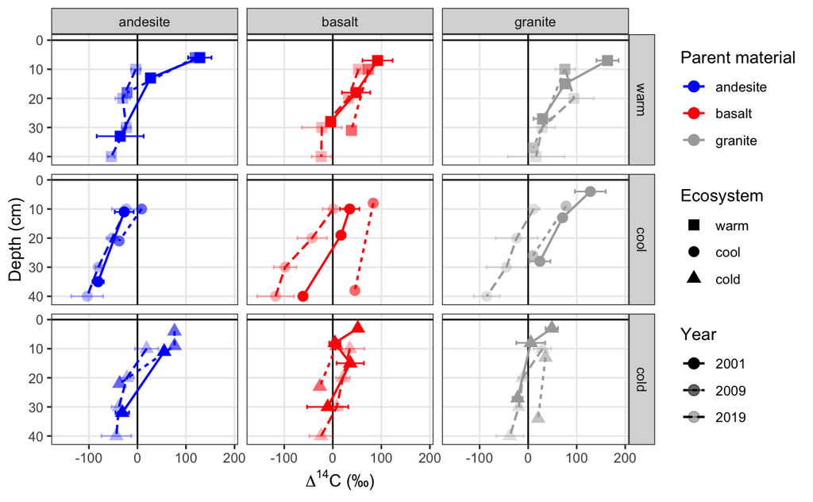

> **Fig. 10. Time series of $\Delta$<sup>14</sup>C by depth, as measured**

> *Caption:* Points show mean of three profile replicates for 2001 and 2019 samples. Error bars show ± 1 standard deviation of the mean (only a single profile was analyzed in 2009).

## Spline fitting

*Fit splines to 2009 data to predict at 2001 depths*

Soils collected in both the 2001 and 2009 sampling campaigns were sampled by horizon, but the depth intervals differed between the two sampling years. In 2009, full profiles were excavated for each site, as opposed to the shorter profiles collected in 2001 from the GR and AN sites. Radiocarbon was measured on all three replicate profiles at each site for the 2001 samples, but only for one of the replicate profiles at each site in 2009, e.g. ANpp rep2, etc.

In order to compare the radiocarbon profiles between 2001, 2009, and 2019 we interpolated both radiocarbon and carbon stock data at 1 cm intervals for each site in the 2009 and 2019 datasets, and then summed the carbon-stock-weighted radiocarbon values for each depth interval sampled in 2001. A monotonic cubic spline fit was used for the carbon stock interpolation (Wendt and Hauser 2013), and a mass-preserving spline was used to fit the radiocarbon data (Bishop, T.F.A., McBratney, A.B., Laslett, G.M., (1999) Modelling soil attribute depth functions with equal-area quadratic smoothing splines. Geoderma, 91(1-2): 27-45).

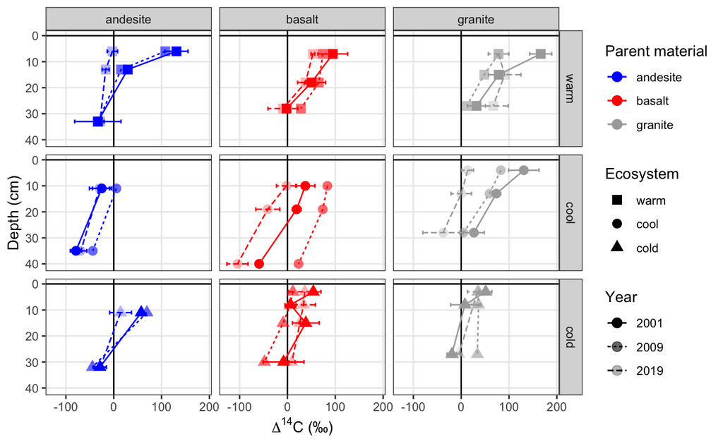

> **Fig. 10. Time series of $\Delta$<sup>14</sup>C by depth (2001, 2009, 2019)**

> *Caption:* Points for 2001 samples show the mean $\Delta$<sup>14</sup>C values at the measured depths. Points for 2009 and 2019 samples are spline-fitted estimates of $\Delta$<sup>14</sup>C predicted for the same depth intervals as measured in 2001. Error bars show ± 1 standard deviation of the mean of three replicate profiles for 2001 and 2019 samples (only a single profile was analyzed in 2009).

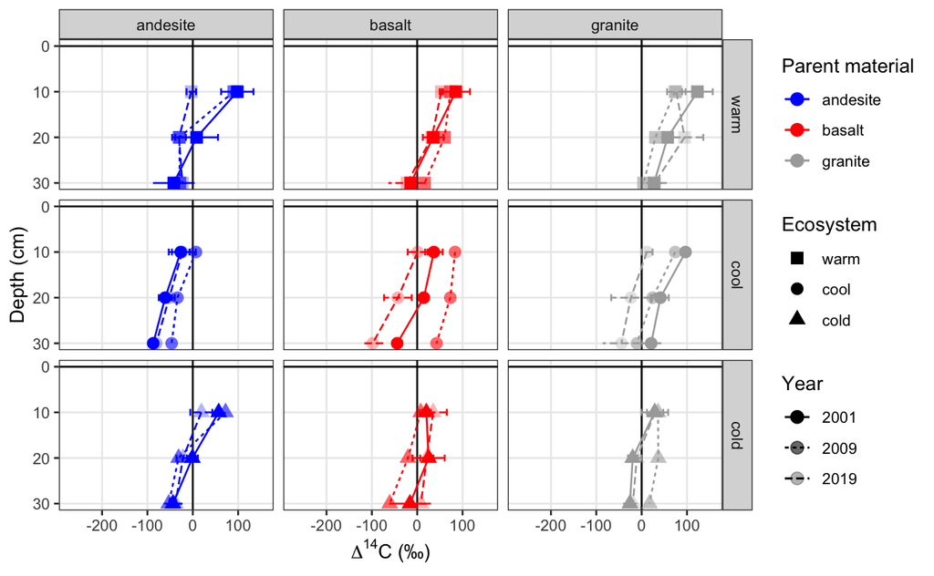

> **Fig. 10. Time series of $\Delta$<sup>14</sup>C by depth (splined to 2019 depths)**

> *Caption:* Points for 2019 samples show the mean $\Delta$<sup>14</sup>C values at the measured depths. Points for 2001 and 2009 samples are spline-fitted estimates of $\Delta$<sup>14</sup>C predicted for the same depth intervals as measured in 2019. Error bars show ± 1 standard deviation of the mean of three replicate profiles for 2001 and 2019 samples (only a single profile was analyzed in 2009). *NB: Only two depth intervals were measured at the cool and cold andesite sites (max depth of 27 and 28 cm, respectively), so linear extrapolation (using the slope of the last 1cm spline-fitted depth increment) was used to extend the profiles to 30 cm.*

## Initial modeling

The goal of this modeling exercise is to see how parent material and climate/ecosystem affect estimates of soil carbon ages and transit times. Bulk soil <sup>14</sup>C observations from 2001, 2009, and 2019 will be used to constrain the carbon models, as well as observations of <sup>14</sup>C-CO<sub>2</sub> from laboratory soil incubations of soils collected in 2001 and 2019. Previous work has indicated that the carbon stocks at these sites is likely at equilibrium, so we will apply the steady-state assumption to the modeling.

### Two-pool parallel model

One pool models have been shown repeatedly to be inadequate for describing soil carbon dynamics. However, as simple models are easier to constrain, we will start with a two-pool parallel model, as this is the simplest model system beyond the single pool approach. The two-pool parallel model requires the following parameters: * decomposition constants for each pool (*k*<sub>1</sub>, *k*<sub>2</sub>) * input partitioning coefficient ($\gamma$) * steady-state carbon stocks (C) * inputs (I) * initial values of <sup>14</sup>C

Decomposition rates (*k*) are related to the amount of <sup>14</sup>C in a pre-bomb system (fraction modern, *F*) at steady-state by the following equations (cf. Schuur, Druffle, and Trumbore, 2016): >**Eq. 1**

$$F = \frac{k}{k + \lambda}$$
>**Eq. 2**

$$k = \frac{\lambda \cdot F}{1 - F}$$
>where $\lambda$ is the radioactive decay constant (1/8267).

As the decomposition rates will vary, the initial <sup>14</sup>C content can be determined dynamically with equation 1.

Carbon stocks are known, while inputs will be estimated and are related to the steady-state conditions by the following equation: >**Eq. 3**

$$I = (k_{1} \cdot C_{1}) + (k_{2} \cdot C_{2})$$
>where *C<sub>1</sub>* and *C<sub>2</sub>* are the carbon stocks of the two model pools.

Both stocks and inputs can be scaled to the known value of the total carbon pool once the steady-state parameters (*k<sub>1</sub>*, *k<sub>2</sub>*, $\gamma$) have been determined. Pool sizes are a function of the inputs and input partitioning coefficient at steady-state.

A Monte-Carlo Markov chain approach will be used for parameter estimation in combination with an initial optimization algorithm to determine the best set of initial parameters.

```
ANpp_0-10 parameter fitting
time: 51.4329760074615
ANrf_0-10 parameter fitting
time: 55.9398519992828
ANwf_0-10 parameter fitting
time: 1.76156016588211
BSpp_0-10 parameter fitting
time: 43.8249349594116
BSrf_0-10 parameter fitting
time: 1.89554636478424
BSwf_0-10 parameter fitting
time: 48.1623330116272
GRpp_0-10 parameter fitting
time: 59.3673658370972
GRrf_0-10 parameter fitting
time: 1.95419168074926
GRwf_0-10 parameter fitting
time: 1.3298514008522
```

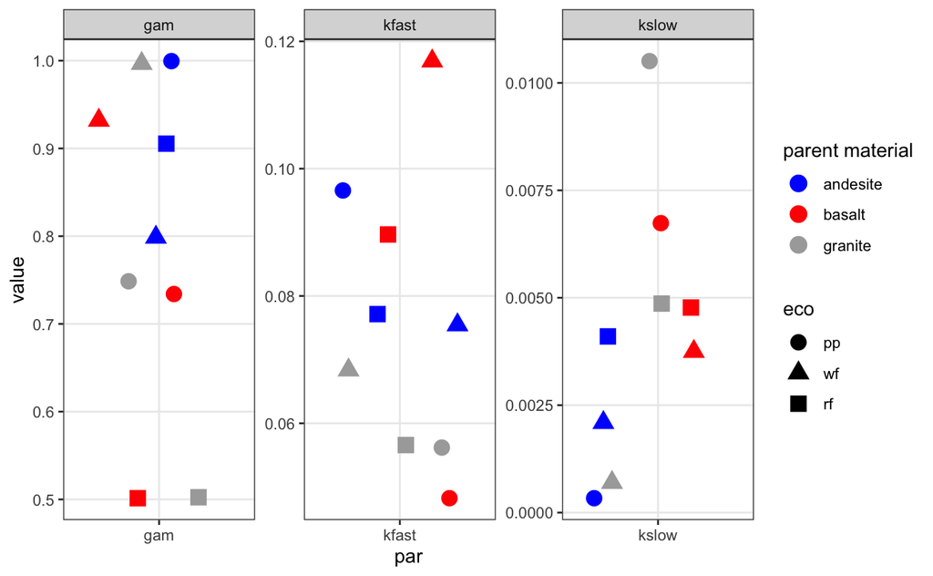

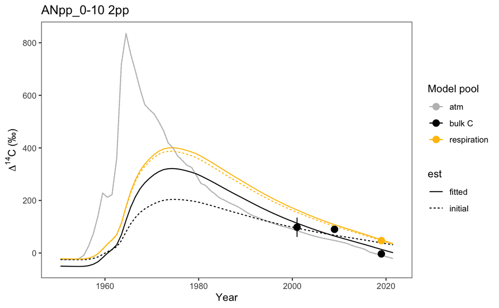

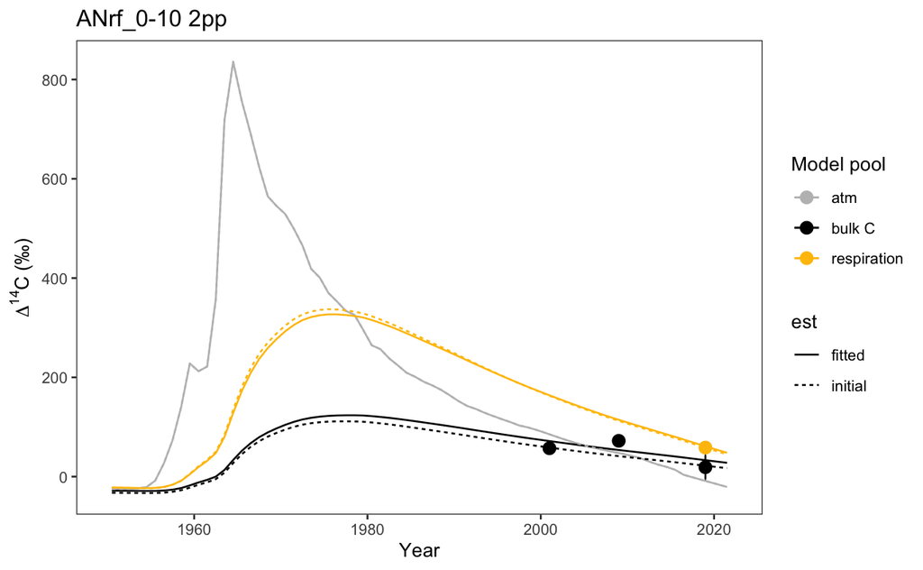

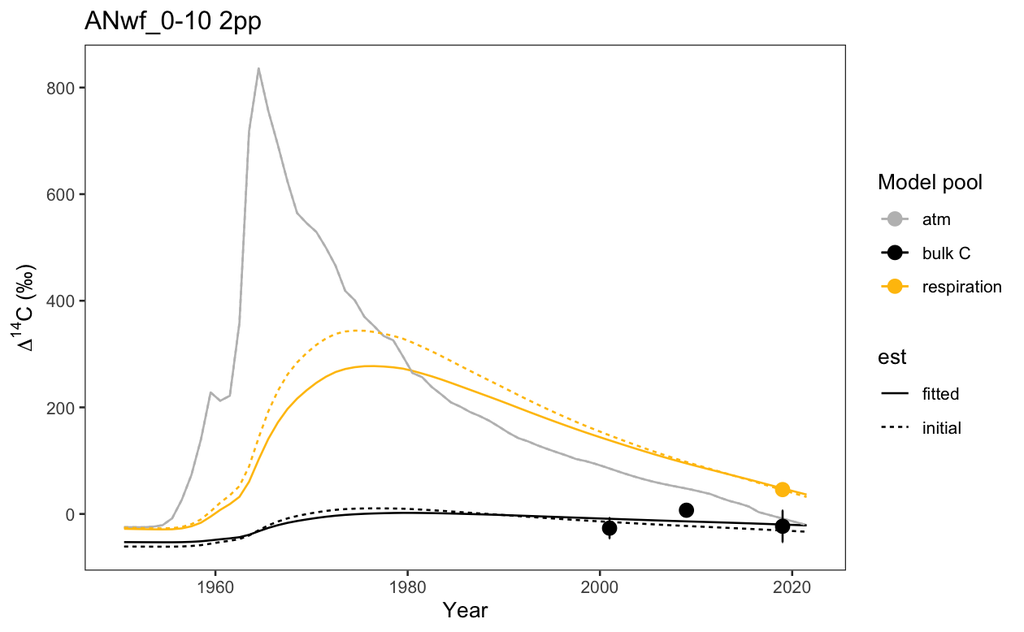

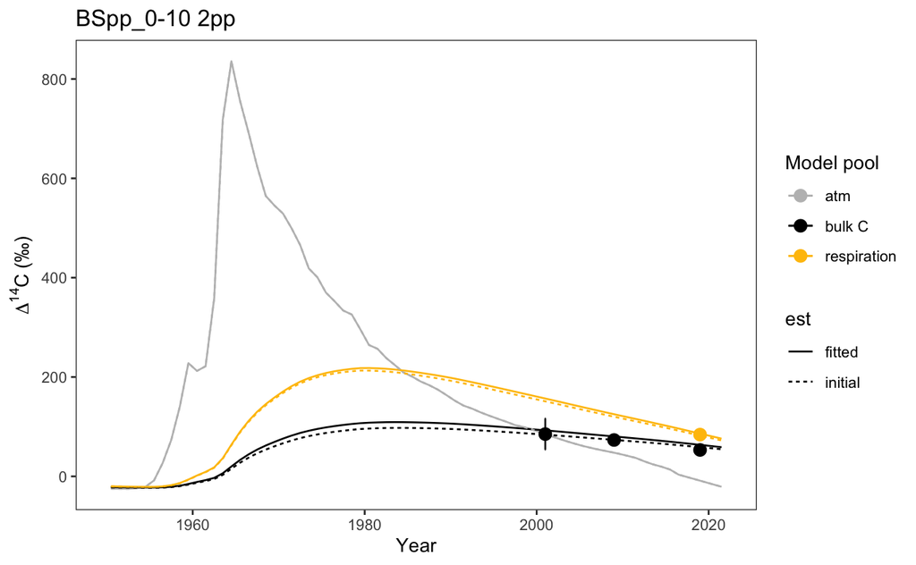

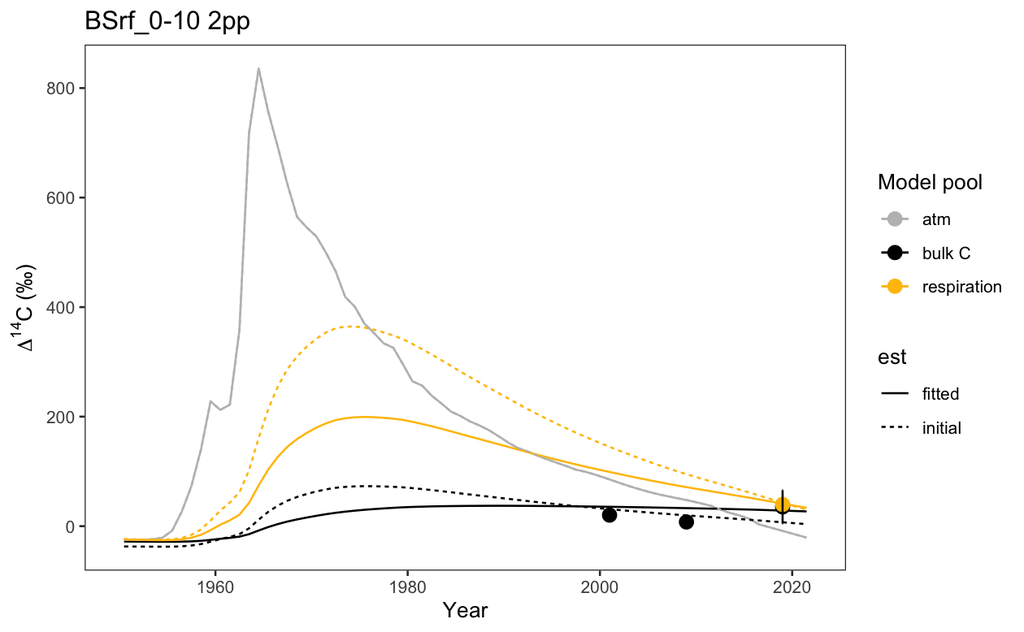

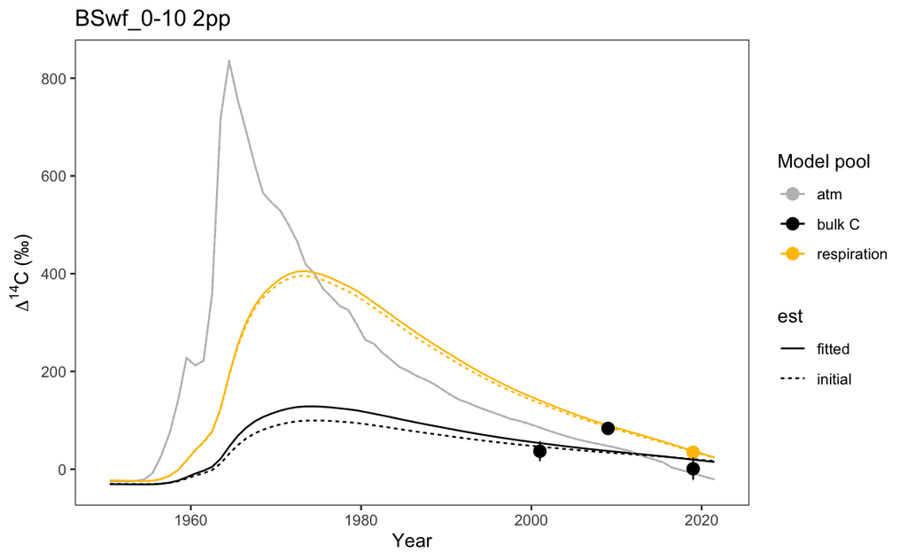

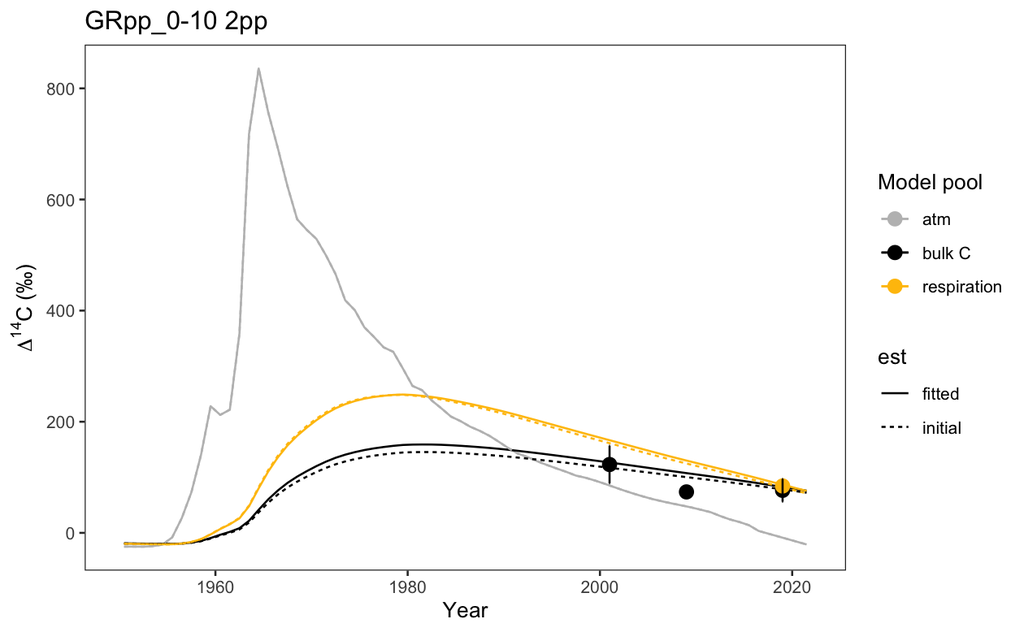

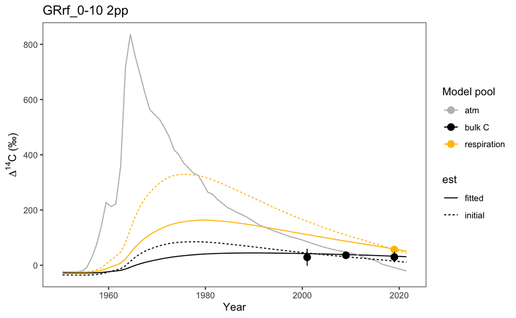

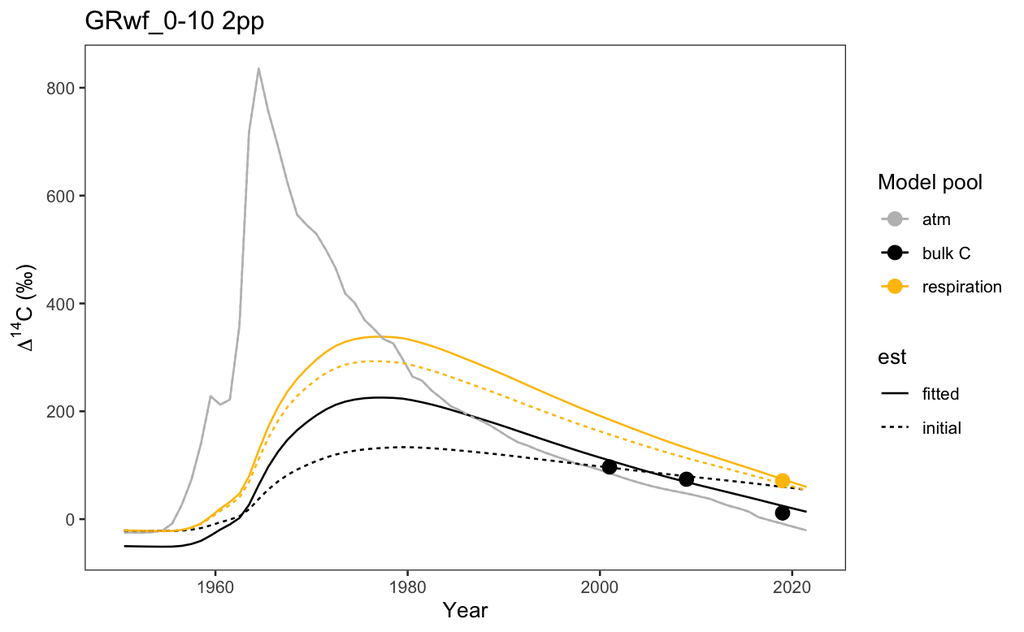